# QTM 151 - Quiz 2

## Try to submit as an HTML file

Print your Emory code below

```python
# Write your answer here
print('2428993')
```

[output not shown]

This quiz is open book

- You can use the lecture notes and Google
- You will get partial credit for attempting the questions
- To get full credit, the code should run as intended
- You should NOT communicate with other students

Print the following message:

"I will abide by Emory's code of conduct"

**By printing the message, you acknowledge that you will abide by Emory's code of conduct.**

```python
# Write your answer here:

print("I will abide by Emory's code of conduct")
```

```
I will abide by Emory's code of conduct
```

Import the libraries "numpy", "matplotlib.pyplot", and "pandas"

```python
# Write your answer here
import pandas as pd
import matplotlib.pyplot as plt
import numpy as np
```

Import the dataset "data_quiz/fifa23_players_basic.csv"

- It's a dataset on professional soccer players
- Rows correspond to players (18,539)
- Columns contain attributes of players (32)
- Try to view the dataset before starting

```python
# Write your own code
fifa = pd.read_csv("data_quiz/fifa23_players_basic.csv")
print(fifa)
```

```
             Known As           Full Name  Overall  Potential  Value(in Euro)  \
0            L. Messi        Lionel Messi       91         91        54000000
1          K. Benzema       Karim Benzema       91         91        64000000
2      R. Lewandowski  Robert Lewandowski       91         91        84000000
3        K. De Bruyne     Kevin De Bruyne       91         91       107500000
4           K. Mbappé       Kylian Mbappé       91         95       190500000
...               ...                 ...      ...        ...             ...
18534      D. Collins      Darren Collins       47         56          110000
18535    Yang Dejiang        Dejiang Yang       47         57           90000
18536       L. Mullan         Liam Mullan       47         67          130000
18537    D. McCallion    Daithí McCallion       47         61          100000
18538        N. Rabha         Nabin Rabha       47         50           60000

      Positions Played Best Position          Nationality  \
0                   RW           CAM            Argentina
```

[output cut: 77 more lines]

(a) Create a function and apply it to a column

Step 1:

- Define a function with a parameter "overall"
- If "overall < 85", status = "Regular Player"
- If "age_player >= 85", status = "Top Player"
- The function returns "status"

Step 2:

- Extract the column "Overall" in the dataset  
  (be carefeful to write the "O" capitalized)
- Create a new variable called "top_players"  
  to assign each player to the correct status

HINT: Use the ".apply()" function

```python
# Write your own code
def fn_fifa (overall):
    if overall < 85:
        status = "Regular Player"
    else:
        status = "Top Player"
    return status

overall_column = fifa['Overall']

fifa['top_players'] = overall_column.apply(fn_fifa)
```

(b) Use queries + global variables

- Compute the mean of the column "Wage(in Euro)"  
  and store it as a variable
- Subset the players whose value is above the mean value  
  using ".query()"

HINT: Remember that there is a special syntax for  
when the column names have spaces (see Lecture 9)  
Reference the column as `` `Wage(in Euro)` `` inside .query()

```python
# Write your own code
mean_wage = fifa['Wage(in Euro)'].mean()
above_mean_wage_players = fifa.query('`Wage(in Euro)` > @mean_wage')

print(mean_wage)
print(above_mean_wage_players)
```

```
8824.537461567506
                 Known As                 Full Name  Overall  Potential  \
0                L. Messi              Lionel Messi       91         91
1              K. Benzema             Karim Benzema       91         91
2          R. Lewandowski        Robert Lewandowski       91         91
3            K. De Bruyne           Kevin De Bruyne       91         91
4               K. Mbappé             Kylian Mbappé       91         95
...                   ...                       ...      ...        ...
14279            A. Lewis                Adam Lewis       61         65
15117           B. Knight                Ben Knight       60         74
15441  T. Suengchitthawon  Thanawat Suengchitthawon       60         70
15957          P. Glatzel              Paul Glatzel       59         65
16157      C. Chukwuemeka         Caleb Chukwuemeka       58         71

       Value(in Euro) Positions Played Best Position Nationality  \
```

[output cut: 78 more lines]

(c) Use sorting + ".iloc[]"

- Use ".sort_values()" to order the "Age" column  
  from youngest to oldest
- Get a subset with the 5 youngest players
- Print their age

```python
# Write your own code
sorted_fifa = fifa.sort_values(by='Age', ascending=True)
youngest_five = sorted_fifa.iloc[:5]
print(youngest_five['Age'])
```

```
17956    16
18014    16
16084    16
11481    16
17591    16
Name: Age, dtype: int64
```

(d) Create a function with four inputs $f(y,x,b0,b1)$

$\qquad e2 = (y - b_0 - b_1 * x)^2$

- The function should return the mean of e2
- This is the mean-square error (mse)
- Call the function "fn_mse"
- Let $y$ be the column "Potential"
- Let $x$ be the column "Age"
- Does  
  $\qquad (b_0 = 80, b_1 = 0.4)$ or  
  $\qquad (b_0 = 80, b_1 =-0.3)$ or  
  $\qquad (b_0 = 80, b_1 = -0.5)$  
  produce the lowest value of mse?
- Print your results

```python
# Write your own code

def fn_mse(y, x, b0, b1):
    e2 = (y - b0 - b1 * x) ** 2
    return e2.mean()

y = fifa['Potential']
x = fifa['Age']

mse_a = fn_mse(y, x, 80, 0.4)
mse_b = fn_mse(y, x, 80, -0.3)
mse_c = fn_mse(y, x, 80, -0.5)

print("The value for MSE_a is: ", mse_a)
print("The value for MSE_b is: ", mse_b)
print("The value for MSE_c is: ", mse_c)

#MSE B (where b0 = 80 and b1 = -.3) has the lowest MSE
```

```
The value for MSE_a is:  412.1016840174767
The value for MSE_b is:  37.72189870003776
The value for MSE_c is:  49.43713253142025
```

(e) Split a dataset into subsets

- Create `list_status = [0,1]`
- Create `list_prob = [0.5, 0.5]`
- Create a new variable $n$ with the number of rows of the dataset
- Define a random seed that equals 42
- Use

```
np.random.choice(list_status,
                     size = n,
                     p = list_prob)
```

$\qquad$ to create a new column called "status"  
$\qquad$ which randomly assigns each row to "0" or "1"  
$\qquad$ with equal probability

- Use .query() to subset all observations with status == 0.  
  store it in a new dataset called "data0"
- Use .query() to subset all observations with status == 1.  
  store it in a new dataset called "data1"

```python
# Write your own code
list_status = [0,1]
list_prob = [.5,.5]

n = len(fifa)
np.random.seed(42)

fifa['status'] = np.random.choice(list_status,
                 size = n,
                 p = list_prob)

data0 = fifa.query('status == 0')
data1 = fifa.query('status == 1')
```

(f) Create two overlapping histogram plots

- This question requires the two datasets you created in (e)
- Display the distribution of "Age" for "data0" and "data1"
- Use the "alpha" option to make the graphs semitransparent
- You will need to add a legend, label the axes, and the title

Note: The goal of this question is to illustrate that random  
assignment produces very similar distributions between two groups

- Provide a short interpretation of the graph using the information from the Note

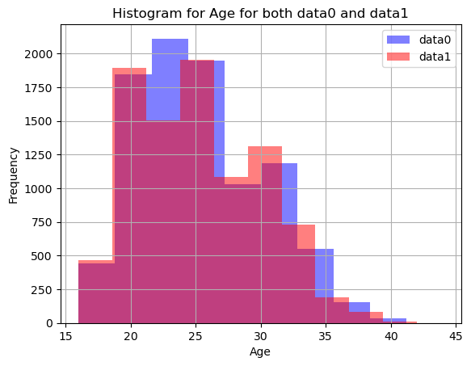

```python
# Write your own code

data0['Age'].hist(alpha=0.5, label='data0', color='blue')
data1['Age'].hist(alpha=0.5, label='data1', color='red')

plt.legend()
plt.xlabel('Age')
plt.ylabel('Frequency')
plt.title('Histogram for Age for both data0 and data1')
plt.show()

#Interpretation: the two overlayed histograms are very similar. The spread of data0 and data1 are almost identical.
#The peak is slightly higher for data0 than for data1 however the spread is almost the exact same. This helps show that when the
#dataset is big enough, and is randomly split into two groups, the distributions should be almost very similar. This is proven by central limit
#theorom and random distribution.
```